# HAR Weight Lifting Exercise

Tomas Rodriguez

January 27, 2019

### Background

#### Using devices such as Jawbone Up, Nike FuelBand, and Fitbit it is now possible to collect a large amount of data about personal activity relatively inexpensively. These type of devices are part of the quantified self movement - a group of enthusiasts who take measurements about themselves regularly to improve their health, to find patterns in their behavior, or because they are tech geeks. One thing that people regularly do is quantify how much of a particular activity they do, but they rarely quantify how well they do it. In this project, your goal will be to use data from accelerometers on the belt, forearm, arm, and dumbell of 6 participants. They were asked to perform barbell lifts correctly and incorrectly in 5 different ways. More information is available from the website here: http://groupware.les.inf.puc-rio.br/har (see the section on the Weight Lifting Exercise Dataset).

### Introduction/Scope

#### The goal of you this analysis is to predict the manner in which participants did the exercise. This is the “classe” variable in the training set. Here we describe how we built your model, how we used cross validation, what we think the expected out of sample error is, and why we made the choices we did. We will also use our prediction model to predict 20 different test cases.

### Experiment Description

#### Six young health participants were asked to perform one set of 10 repetitions of the Unilateral Dumbbell Biceps Curl in five different fashions: exactly according to the specification (Class A), throwing the elbows to the front (Class B), lifting the dumbbell only halfway (Class C), lowering the dumbbell only halfway (Class D) and throwing the hips to the front (Class E). Sensors were placed at four locations: belt, arm, dumbbell, and forearm. The output of the sensor data become the input files to our analysis.

### Data URL

#### Training Data: https://d396qusza40orc.cloudfront.net/predmachlearn/pml-training.csv

#### Test Data: https://d396qusza40orc.cloudfront.net/predmachlearn/pml-testing.csv

### Analysis Repository

#### URL: https://github.com/tomyr95/har

# Environment Setup

```r
  library(caret); library(dplyr); library(Hmisc); library(car); library(corrplot)
  library(rattle); library(rpart); library(parallel); library(doParallel)
  library(e1071); library(ggplot2); library(klaR); library(stringr)
  library(lattice); library(beepr); library(grid); library(gridExtra)
```

# Download/Read Data

1. We downloaded the training/testing data into our working directory.
2. We assined it to objects dat1 and dat2, respectively.

```r
  url1 <- "https://d396qusza40orc.cloudfront.net/predmachlearn/pml-training.csv"
  url2 <- "https://d396qusza40orc.cloudfront.net/predmachlearn/pml-testing.csv"
  download.file(url1, "training.csv")
  download.file(url2, "testing.csv")

  dat1 <- read.csv("training.csv")
  dat2 <- read.csv("testing.csv")
```

# Inspect/Cleanup/Partition Data

1. In reviewing the data we find many zero, nezr-zero, and columns containing only NA.
2. In addition we see a number of columns that are not pertinent to our analysis.
3. We removed such columns for both the trainig (dat1) and testing (dat2) data.
4. We split original trainig data into training(TRIAN)/validation(VAL) sets.
5. We assign testing data and remove dat, dat2 placeholders.

```r
  str(dat1)
```

```
## 'data.frame':    19622 obs. of  160 variables:
##  $ X                       : int  1 2 3 4 5 6 7 8 9 10 ...
##  $ user_name               : Factor w/ 6 levels "adelmo","carlitos",..: 2 2 2 2 2 2 2 2 2 2 ...
##  $ raw_timestamp_part_1    : int  1323084231 1323084231 1323084231 1323084232 1323084232 1323084232 1323084232 1323084232 1323084232 1323084232 ...
##  $ raw_timestamp_part_2    : int  788290 808298 820366 120339 196328 304277 368296 440390 484323 484434 ...
##  $ cvtd_timestamp          : Factor w/ 20 levels "02/12/2011 13:32",..: 9 9 9 9 9 9 9 9 9 9 ...
##  $ new_window              : Factor w/ 2 levels "no","yes": 1 1 1 1 1 1 1 1 1 1 ...
##  $ num_window              : int  11 11 11 12 12 12 12 12 12 12 ...
##  $ roll_belt               : num  1.41 1.41 1.42 1.48 1.48 1.45 1.42 1.42 1.43 1.45 ...
##  $ pitch_belt              : num  8.07 8.07 8.07 8.05 8.07 8.06 8.09 8.13 8.16 8.17 ...
##  $ yaw_belt                : num  -94.4 -94.4 -94.4 -94.4 -94.4 -94.4 -94.4 -94.4 -94.4 -94.4 ...
##  $ total_accel_belt        : int  3 3 3 3 3 3 3 3 3 3 ...
##  $ kurtosis_roll_belt      : Factor w/ 397 levels "","-0.016850",..: 1 1 1 1 1 1 1 1 1 1 ...
##  $ kurtosis_picth_belt     : Factor w/ 317 levels "","-0.021887",..: 1 1 1 1 1 1 1 1 1 1 ...
##  $ kurtosis_yaw_belt       : Factor w/ 2 levels "","#DIV/0!": 1 1 1 1 1 1 1 1 1 1 ...
```

[output cut: 86 more lines]

```r
  dat1 <- dat1[,-c(1:7)] #Remove 1st columns with identifying data, not for processing
  dat1 <- dat1[, -nearZeroVar(dat1)] #Remove all zero and near-zero values
  dat1 <- dat1[ , colSums(is.na(dat1)) == 0] #Remove all only NA columns
  dat1$id <- c(1:nrow(dat1)) #Added simple 'id' for reference purposes.

  #Apply same transformations to dat2(testing data)
  dat2 <- dat2[,-c(1:7)]
  dat2 <- dat2[, -nearZeroVar(dat2)]
  dat2 <- dat2[ , colSums(is.na(dat2)) == 0]

  #Divide training (dat1) into training(TRAIN)/validation(VAL) datasets
  set.seed(333)
  inTrain <- createDataPartition(y = dat1$classe, p=0.75)[[1]]
  TRAIN <- dat1[inTrain,]
  VAL <- dat1[-inTrain,]

  #Verify outcome (classe) proportionally distributed (expected)
  table(TRAIN$classe)
```

```
##
##    A    B    C    D    E
## 4185 2848 2567 2412 2706
```

```r
  table(VAL$classe)
```

```
##
##    A    B    C    D    E
## 1395  949  855  804  901
```

```r
  testing <-dat2

  remove(dat1)
  remove(dat2)
```

# Review Data

1. We note columns called ‘total_accel’ and suspect they are functions of other predictors.
2. We will use ‘featureplot’ function to review for potential outliers in the data.
3. We will leave review of potential important predictors to the selected model.
4. One can get a sense of important features “pairs” and“density plot types.
5. Saved feature plots in: har-featureset1.png (2, 3, 4).
6. Removed four (4) points as suspected outliers.

```r
names(TRAIN)
```

```
##  [1] "roll_belt"            "pitch_belt"           "yaw_belt"
##  [4] "total_accel_belt"     "gyros_belt_x"         "gyros_belt_y"
##  [7] "gyros_belt_z"         "accel_belt_x"         "accel_belt_y"
## [10] "accel_belt_z"         "magnet_belt_x"        "magnet_belt_y"
## [13] "magnet_belt_z"        "roll_arm"             "pitch_arm"
## [16] "yaw_arm"              "total_accel_arm"      "gyros_arm_x"
## [19] "gyros_arm_y"          "gyros_arm_z"          "accel_arm_x"
## [22] "accel_arm_y"          "accel_arm_z"          "magnet_arm_x"
## [25] "magnet_arm_y"         "magnet_arm_z"         "roll_dumbbell"
## [28] "pitch_dumbbell"       "yaw_dumbbell"         "total_accel_dumbbell"
## [31] "gyros_dumbbell_x"     "gyros_dumbbell_y"     "gyros_dumbbell_z"
## [34] "accel_dumbbell_x"     "accel_dumbbell_y"     "accel_dumbbell_z"
## [37] "magnet_dumbbell_x"    "magnet_dumbbell_y"    "magnet_dumbbell_z"
## [40] "roll_forearm"         "pitch_forearm"        "yaw_forearm"
## [43] "total_accel_forearm"  "gyros_forearm_x"      "gyros_forearm_y"
## [46] "gyros_forearm_z"      "accel_forearm_x"      "accel_forearm_y"
## [49] "accel_forearm_z"      "magnet_forearm_x"     "magnet_forearm_y"
## [52] "magnet_forearm_z"     "classe"               "id"
```

```r
plot1 <- featurePlot(x=TRAIN[, 1:3], y=TRAIN$classe, plot="box")   # BELT rpy        (r p y)
plot2 <- featurePlot(x=TRAIN[, 5:7], y=TRAIN$classe, plot="box")   # BELT gyrow      (LOW)
plot3 <- featurePlot(x=TRAIN[, 8:10], y=TRAIN$classe, plot="box")  # BELT accel      (x y z)
plot4 <- featurePlot(x=TRAIN[, 11:13], y=TRAIN$classe, plot="box") # BELT magnet     (x)
png('har-featureset1.png', width = 10, height = 7.5, units = 'in', res = 300)
grid.arrange(plot1, plot2, plot3, plot4, ncol=2, nrow=2)
dev.off()
```

```r
plot1 <- featurePlot(x=TRAIN[, 14:16], y=TRAIN$classe, plot="box", no.axes=TRUE) # ARM rpy         (r)
plot2 <- featurePlot(x=TRAIN[, 18:20], y=TRAIN$classe, plot="box", no.axes=TRUE) # ARM gyros       (LOW)
plot3 <- featurePlot(x=TRAIN[, 21:23], y=TRAIN$classe, plot="box") # ARM accel       (z)
plot4 <- featurePlot(x=TRAIN[, 24:26], y=TRAIN$classe, plot="box") # ARM magnet      (LOW)
png('har-featureset2.png', width = 10, height = 7.5, units = 'in', res = 300)
grid.arrange(plot1, plot2, plot3, plot4, ncol=2, nrow=2)
dev.off()
```

```r
plot1 <- featurePlot(x=TRAIN[, 27:29], y=TRAIN$classe, plot="box") # DUMBBELL rpy    (LOW)
plot2 <- featurePlot(x=TRAIN[, 31:33], y=TRAIN$classe, plot="box") # DUMBBELL gyros  (LOW)
plot3 <- featurePlot(x=TRAIN[, 34:36], y=TRAIN$classe, plot="box") # DUMBBELL accel  (y)
plot4 <- featurePlot(x=TRAIN[, 37:39], y=TRAIN$classe, plot="box") # DUMBELL magnet  (y z)
png('har-featureset3.png', width = 10, height = 7.5, units = 'in', res = 300)
grid.arrange(plot1, plot2, plot3, plot4, ncol=2, nrow=2)
dev.off()
```

```r
plot1 <- featurePlot(x=TRAIN[, 40:42], y=TRAIN$classe, plot="box") # FOREARM rpy     (LOW)
plot2 <- featurePlot(x=TRAIN[, 44:46], y=TRAIN$classe, plot="box") # FOREARM gyros   (LOW)
plot3 <- featurePlot(x=TRAIN[, 47:49], y=TRAIN$classe, plot="box") # FOREARM Accel   (z)
plot4 <- featurePlot(x=TRAIN[, c(4, 17, 30, 43)], y=TRAIN$classe, plot="box")           # f(predictors)
png('har-featureset4.png', width = 10, height = 7.5, units = 'in', res = 300)
grid.arrange(plot1, plot2, plot3, plot4, ncol=2, nrow=2)
dev.off()
```

# Remove Outliers (Based on extreme observations ONLY in this rather large data set)

```r
TRAIN <- TRAIN[TRAIN$id!=5373,]
TRAIN <- TRAIN[TRAIN$id!=9274,]
TRAIN <- TRAIN[TRAIN$id!=152,]
TRAIN <- TRAIN[TRAIN$id!=9941,]

#Remove id column for rest of analysis
TRAIN <- TRAIN[, -ncol(TRAIN)]
VAL <- VAL[, -ncol(VAL)]
```

# Sample Smaller Dataset for Model Spot Check

```r
  set.seed(333)
  sampleTRAIN <- createDataPartition(y = TRAIN$classe, p=0.05)[[1]]
  sampleVAL <- createDataPartition(y = VAL$classe, p=0.05)[[1]]
  smlTr <- TRAIN[sampleTRAIN,]
  smlVal <- VAL[sampleVAL,]
  table(smlTr$classe)
```

```
##
##   A   B   C   D   E
## 210 143 129 121 136
```

```r
  table(smlVal$classe)
```

```
##
##  A  B  C  D  E
## 70 48 43 41 46
```

# Model Spot Check

1- Model Spot Check/Selection performed for a selection of models discussed in class 2- Class: Data Science/Practical Machine Learning, John’s Hopkins University, Bis-Statistics. 3- Random Forrest was found to be the most accurate model to fit the training data set. 4- Top performing models highly correlated, so don’t consider stacking.

```r
  control <- trainControl(method="repeatedcv", number=5, repeats=3)

  # Linear Discriminant Analysis
  set.seed(333)
  start <- Sys.time()
  fit.lda <- train(classe~., data=smlTr, method="lda", metric="Accuracy", preProc=c("center", "scale"), trControl=control)
  end <- Sys.time()
  prediction <-predict(fit.lda, smlTr[, -ncol(smlTr)])
  time.lda <- end - start
  p.lda<-prediction

  # CART
  set.seed(333)
  start <- Sys.time()
  fit.rpart <- train(classe~., data=smlTr, method="rpart", metric="Accuracy", trControl=control)
  end <- Sys.time()
  prediction <-predict(fit.lda, smlTr[, -ncol(smlTr)])
  time.rpart <- end - start
  p.rpart<-prediction

  # Bagging
  set.seed(333)
  start <- Sys.time()
  fit.treebag <- train(classe~., data=smlTr, method="treebag", metric="Accuracy", trControl=control, verbose=FALSE)
  end <- Sys.time()
  prediction <-predict(fit.treebag, smlTr[, -ncol(smlTr)])
  time.treebag <- end - start
  p.treebag<-prediction

  # Random Forest
  set.seed(333)
  start <- Sys.time()
  fit.rf <- train(classe~., data=smlTr, method="rf", metric="Accuracy", trControl=control)
  end <- Sys.time()
  prediction <-predict(fit.rf, smlTr[, -ncol(smlTr)])
  time.rf <- end - start
  p.rf<-prediction

  # Boosting
  set.seed(333)
  start <- Sys.time()
  fit.gbm <- train(classe~., data=smlTr, method="gbm", metric="Accuracy", trControl=control, verbose=FALSE)
  end <- Sys.time()
  prediction <-predict(fit.gbm, smlTr[, -ncol(smlTr)])
  time.gbm <- end - start
  p.gbm<-prediction

  # Summarize Results
  results <- resamples(list(lda=fit.lda, rpart=fit.rpart, treebag=fit.treebag, rf=fit.rf, gbm=fit.gbm))
  sum_df <- summary(results)
  times <- data.frame("names"=c("lda", "rpart", "treebag", "rf", "gbm"),
             "times"=c(time.lda, time.rpart, time.treebag, time.rf, time.gbm))
  print(sum_df)
```

```
##
## Call:
## summary.resamples(object = results)
##
## Models: lda, rpart, treebag, rf, gbm
## Number of resamples: 15
##
## Accuracy
##              Min.   1st Qu.    Median      Mean   3rd Qu.      Max. NA's
## lda     0.6510067 0.6790541 0.7006803 0.6982023 0.7084712 0.7567568    0
## rpart   0.3493151 0.4142481 0.5135135 0.4812041 0.5457575 0.5918367    0
## treebag 0.8053691 0.8282922 0.8424658 0.8502487 0.8682432 0.9127517    0
## rf      0.8287671 0.8644052 0.8657718 0.8713961 0.8775454 0.9121622    0
## gbm     0.8219178 0.8469388 0.8724832 0.8668945 0.8851351 0.8993289    0
##
## Kappa
##               Min.   1st Qu.    Median      Mean   3rd Qu.      Max. NA's
## lda     0.55979774 0.5952985 0.6215331 0.6183161 0.6316898 0.6919163    0
## rpart   0.09458842 0.2236695 0.3707334 0.3211274 0.4192747 0.4757489    0
## treebag 0.75264755 0.7822194 0.8001904 0.8103907 0.8335176 0.8898430    0
## rf      0.78389580 0.8279657 0.8304313 0.8371203 0.8452043 0.8886896    0
## gbm     0.77554399 0.8060610 0.8394670 0.8316022 0.8545664 0.8726786    0
```

```r
  print(times)
```

```
##     names           times
## 1     lda  0.7701921 secs
## 2   rpart  0.8768082 secs
## 3 treebag  6.9227722 secs
## 4      rf 42.2010620 secs
## 5     gbm 27.9692690 secs
```

```r
  #Access correlation between Top performing models
  confusionMatrix(p.rf, p.gbm)
```

```
## Confusion Matrix and Statistics
##
##           Reference
## Prediction   A   B   C   D   E
##          A 210   0   0   0   0
##          B   0 143   0   0   0
##          C   0   0 129   0   0
##          D   0   0   0 121   0
##          E   0   0   0   0 136
##
## Overall Statistics
##
##                Accuracy : 1
##                  95% CI : (0.995, 1)
##     No Information Rate : 0.2842
##     P-Value [Acc > NIR] : < 2.2e-16
##
##                   Kappa : 1
##  Mcnemar's Test P-Value : NA
##
## Statistics by Class:
##
##                      Class: A Class: B Class: C Class: D Class: E
## Sensitivity            1.0000   1.0000   1.0000   1.0000    1.000
## Specificity            1.0000   1.0000   1.0000   1.0000    1.000
## Pos Pred Value         1.0000   1.0000   1.0000   1.0000    1.000
## Neg Pred Value         1.0000   1.0000   1.0000   1.0000    1.000
## Prevalence             0.2842   0.1935   0.1746   0.1637    0.184
## Detection Rate         0.2842   0.1935   0.1746   0.1637    0.184
## Detection Prevalence   0.2842   0.1935   0.1746   0.1637    0.184
## Balanced Accuracy      1.0000   1.0000   1.0000   1.0000    1.000
```

```r
  confusionMatrix(p.rf, p.treebag)
```

```
## Confusion Matrix and Statistics
##
##           Reference
## Prediction   A   B   C   D   E
##          A 210   0   0   0   0
##          B   0 143   0   0   0
##          C   0   0 129   0   0
##          D   0   0   0 121   0
##          E   0   0   0   0 136
##
## Overall Statistics
##
##                Accuracy : 1
##                  95% CI : (0.995, 1)
##     No Information Rate : 0.2842
##     P-Value [Acc > NIR] : < 2.2e-16
##
##                   Kappa : 1
##  Mcnemar's Test P-Value : NA
##
## Statistics by Class:
##
##                      Class: A Class: B Class: C Class: D Class: E
## Sensitivity            1.0000   1.0000   1.0000   1.0000    1.000
## Specificity            1.0000   1.0000   1.0000   1.0000    1.000
## Pos Pred Value         1.0000   1.0000   1.0000   1.0000    1.000
## Neg Pred Value         1.0000   1.0000   1.0000   1.0000    1.000
## Prevalence             0.2842   0.1935   0.1746   0.1637    0.184
## Detection Rate         0.2842   0.1935   0.1746   0.1637    0.184
## Detection Prevalence   0.2842   0.1935   0.1746   0.1637    0.184
## Balanced Accuracy      1.0000   1.0000   1.0000   1.0000    1.000
```

# Run Ramdom Forrest, All Predictors

1- Run RF model with all predictors and full TRAIN data to assess predictor importance (varImp).

```r
  set.seed(333)
  training <- TRAIN
  validation <- VAL
  fitControl <- trainControl(method="repeatedcv", number=5, repeats=3)
  start <- Sys.time()
  fit <- train(classe ~., method = "rf", data = training, trControl = fitControl, importance=TRUE)
  end <- Sys.time()
  timeRF <- end - start
  pTr <-predict(fit, training[, -ncol(training)])
  pVal <-predict(fit, validation[, -ncol(validation)])
  accTr <-confusionMatrix(pTr, training[, ncol(training)])$overall['Accuracy']
  accVal <-confusionMatrix(pVal, validation[, ncol(validation)])$overall['Accuracy']
  fitRF <- fit
  Imp <- varImp(fitRF)$importance
  Imp$names <- rownames(Imp)
  features <- Imp %>% mutate(id = row_number()) %>% mutate(sum = A+B+C+D+E) %>% arrange(desc(sum))
  cols_all <- features$id
  print(features)
```

```
##            A        B        C         D        E                names id
## 1  92.142513 91.79959 73.67040 100.00000 49.68146             yaw_belt  3
## 2  64.714729 91.16680 93.54129  91.39563 59.73162            roll_belt  1
## 3  64.893533 96.28356 77.44490  70.01059 63.82285           pitch_belt  2
## 4  71.154332 68.37430 90.74185  69.87000 56.76221    magnet_dumbbell_z 39
## 5  47.460311 78.58983 68.21261  58.40571 47.96653             roll_arm 14
## 6  45.664579 70.00607 59.00961  64.56742 54.39833     accel_dumbbell_y 35
## 7  44.158528 72.13908 60.32763  54.33492 50.97969         gyros_belt_z  7
## 8  49.470478 55.03912 79.08787  54.25863 41.64644    magnet_dumbbell_y 38
## 9  38.911396 59.82930 51.81152  61.22643 52.05880        pitch_forearm 41
## 10 42.321806 60.37897 56.49821  54.29630 35.74546         accel_belt_z 10
## 11 39.119267 58.42879 59.41469  49.42798 41.97304     gyros_dumbbell_y 32
## 12 45.010735 53.48937 51.50906  47.58077 47.77110     accel_dumbbell_z 36
## 13 43.616975 50.96397 48.48822  52.26668 38.59675        magnet_belt_y 12
## 14 25.564560 55.44133 53.10733  39.03143 60.44291        magnet_belt_x 11
```

[output cut: 91 more lines]

```r
  df <- data.frame(c("features", "timeRF", "accTr", "accVal"), c(ncol(training)-1, timeRF, accTr, accVal))
  df
```

```
##   c..features....timeRF....accTr....accVal..
## 1                                   features
## 2                                     timeRF
## 3                                      accTr
## 4                                     accVal
##   c.ncol.training....1..timeRF..accTr..accVal.
## 1                                    52.000000
## 2                                    45.208954
## 3                                     1.000000
## 4                                     0.995106
```

```r
  cols_all
```

```
##  [1]  3  1  2 39 14 35  7 38 41 10 32 36 12 11 16 52 19 34 30 13 49 33 27
## [24] 51 42 22 47 37 40 26 31 29 48 43 46  5 44  8  4 21 45 23 50  9 18 25
## [47] 15 28  6 24 20 17
```

# Create Dataframe for Fit Results by Predictor Quantity

```r
  pQty <- data.frame(matrix(ncol=3, nrow=0))
  colnames(pQty) <- c("Pred", "Time", "OOS")
```

# Optimize Predictor Selection

1- To prevent underfitting or overfitting the model we will use out-of-sample (OOS) error estimation. 2- The goal is to find the number of predictors that minimize the OOS error rate. 3- We wil use the validation (VAL) dataset predictions to assess OOS error. 4- This was done manually and stored in object “Multi_Parameter.rds”. 5- OOS error (1-accuracy) will not reduce predictor quantity.

```r
  set.seed(333)
  redNum <- 5
  redFeatures <- head(features$id, redNum)
  cols <- append(redFeatures, ncol(TRAIN), after = length(redFeatures))
  training <- TRAIN[, cols]
  fitcontrol <- trainControl(method="repeatedcv", number=5, repeats=3)
  start <- Sys.time()
  fit <- train(classe ~., method = "rf", data = training, trControl = fitControl, importance=TRUE)
  end <- Sys.time()
  pVal <-predict(fit, validation[, -ncol(validation)])
  fitRF <- fit
  timeRF <- end - start
  accVal <-confusionMatrix(pVal, validation[, ncol(validation)])$overall['Accuracy']
  pQty[nrow(pQty) + 1,] = list(redNum, timeRF, accVal)
  save(pQty, file = "Multi_Parameter.rds")
```

# Plot Predictors vs. OOS Error

```r
load("Multi_Parameter.rds")
print(pQty)
```

```
##    Pred      Time       OOS
## 1     5  4.037030 0.9708401
## 2    10  6.982997 0.9908238
## 3    15 10.259109 0.9908238
## 4    20 14.318595 0.9918434
## 5    25 18.555994 0.9916395
## 6     7  5.294556 0.9820555
## 7    35 23.467394 0.9934747
## 8    30 19.846859 0.9930669
## 9    40 27.086994 0.9944943
## 10   50 35.079192 0.9946982
## 11   45 32.006012 0.9946982
## 13   52 37.131802 0.9944943
```

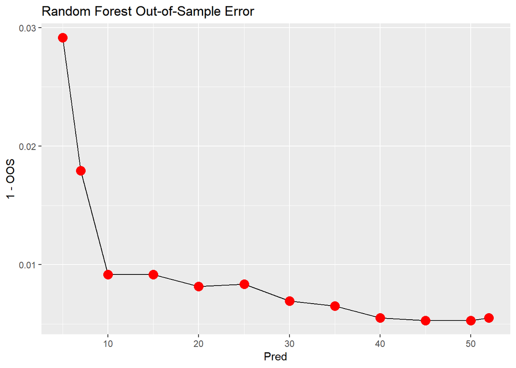

```r
g = ggplot(pQty, aes(y=1-OOS, x=Pred))
    g = g + geom_line()
    g = g + geom_point(color="RED", size=4)
    g = g + ggtitle("Random Forest Out-of-Sample Error")
    g
```

# Run Test Data On Selected Model

1- We run the test data for the selected model and have the following results. 2- These results will be submitted to the Course Project Prediction Quiz.

```r
  predict(fit, testing)
```

```
##  [1] B A B A A E D B A A B C B A E E A B B B
## Levels: A B C D E
```

# Conclusions

1- A model can be adequately done -in this case- random forrest to predict exercise manner. 2- Our predicted results: B A B A A E D B A A B C B A E E A B B B.

# References

1- “How to Evaluate Machine Learning Algorithms with R” by Jason Brownlee on February 1, 2016 in R Machine Learning. 2- Velloso, E.; Bulling, A.; Gellersen, H.; Ugulino, W.; Fuks, H., Qualitative Activity Recognition of Weight Lifting Exercises. Proceedings of 4th International Conference in Cooperation with SIGCHI (Augmented Human ’13) . Stuttgart, Germany: ACM SIGCHI, 2013.